# Dataset Description

The dataset for this competition (both train and test) was generated from a deep learning model trained on the Depression Survey/Dataset for Analysis dataset. Feature distributions are close to, but not exactly the same, as the original. Feel free to use the original dataset as part of this competition, both to explore differences as well as to see whether incorporating the original in training improves model performance.

# Notes:

A number of data artifacts have been left in the synthetic dataset. This is not a particularly difficult dataset to model. It may be interesting to focus on different ways to visualize the dataset.

Files

```python
import pandas as pd
import matplotlib.pyplot as plt
import seaborn as sns
import numpy as np

from sklearn.preprocessing import OneHotEncoder, OrdinalEncoder, StandardScaler, MinMaxScaler, RobustScaler, LabelEncoder
from sklearn.impute import SimpleImputer
from sklearn.model_selection import train_test_split
from sklearn.metrics import accuracy_score, confusion_matrix, ConfusionMatrixDisplay
from sklearn.pipeline import Pipeline
from sklearn.compose import ColumnTransformer
from sklearn.model_selection import RandomizedSearchCV,GridSearchCV
from sklearn.neighbors import KNeighborsClassifier
from sklearn.tree import DecisionTreeClassifier
from xgboost import XGBClassifier
from catboost import CatBoostClassifier
from sklearn.ensemble import GradientBoostingClassifier
from catboost import CatBoostClassifier
```

```python
train = pd.read_csv('train.csv').set_index('id')
train.name = 'train'
test = pd.read_csv('test.csv').set_index('id')
test.name = 'test'
print(train.name),display(train.head());
```

```
train
```

| id | Name | Gender | Age | City | Working Professional or Student | Profession | Academic Pressure | Work Pressure | CGPA | Study Satisfaction | Job Satisfaction | Sleep Duration | Dietary Habits | Degree | Have you ever had suicidal thoughts ? | Work/Study Hours | Financial Stress | Family History of Mental Illness | Depression |
| --- | --- | --- | --- | --- | --- | --- | --- | --- | --- | --- | --- | --- | --- | --- | --- | --- | --- | --- | --- |
| 0 | Aaradhya | Female | 49.0 | Ludhiana | Working Professional | Chef | NaN | 5.0 | NaN | NaN | 2.0 | More than 8 hours | Healthy | BHM | No | 1.0 | 2.0 | No | 0 |
| 1 | Vivan | Male | 26.0 | Varanasi | Working Professional | Teacher | NaN | 4.0 | NaN | NaN | 3.0 | Less than 5 hours | Unhealthy | LLB | Yes | 7.0 | 3.0 | No | 1 |
| 2 | Yuvraj | Male | 33.0 | Visakhapatnam | Student | NaN | 5.0 | NaN | 8.97 | 2.0 | NaN | 5-6 hours | Healthy | B.Pharm | Yes | 3.0 | 1.0 | No | 1 |
| 3 | Yuvraj | Male | 22.0 | Mumbai | Working Professional | Teacher | NaN | 5.0 | NaN | NaN | 1.0 | Less than 5 hours | Moderate | BBA | Yes | 10.0 | 1.0 | Yes | 1 |
| 4 | Rhea | Female | 30.0 | Kanpur | Working Professional | Business Analyst | NaN | 1.0 | NaN | NaN | 1.0 | 5-6 hours | Unhealthy | BBA | Yes | 9.0 | 4.0 | Yes | 0 |

```python
print(test.name),display(test.head());
```

```
test
```

| id | Name | Gender | Age | City | Working Professional or Student | Profession | Academic Pressure | Work Pressure | CGPA | Study Satisfaction | Job Satisfaction | Sleep Duration | Dietary Habits | Degree | Have you ever had suicidal thoughts ? | Work/Study Hours | Financial Stress | Family History of Mental Illness |
| --- | --- | --- | --- | --- | --- | --- | --- | --- | --- | --- | --- | --- | --- | --- | --- | --- | --- | --- |
| 140700 | Shivam | Male | 53.0 | Visakhapatnam | Working Professional | Judge | NaN | 2.0 | NaN | NaN | 5.0 | Less than 5 hours | Moderate | LLB | No | 9.0 | 3.0 | Yes |
| 140701 | Sanya | Female | 58.0 | Kolkata | Working Professional | Educational Consultant | NaN | 2.0 | NaN | NaN | 4.0 | Less than 5 hours | Moderate | B.Ed | No | 6.0 | 4.0 | No |
| 140702 | Yash | Male | 53.0 | Jaipur | Working Professional | Teacher | NaN | 4.0 | NaN | NaN | 1.0 | 7-8 hours | Moderate | B.Arch | Yes | 12.0 | 4.0 | No |
| 140703 | Nalini | Female | 23.0 | Rajkot | Student | NaN | 5.0 | NaN | 6.84 | 1.0 | NaN | More than 8 hours | Moderate | BSc | Yes | 10.0 | 4.0 | No |
| 140704 | Shaurya | Male | 47.0 | Kalyan | Working Professional | Teacher | NaN | 5.0 | NaN | NaN | 5.0 | 7-8 hours | Moderate | BCA | Yes | 3.0 | 4.0 | No |

```python
print(train.name),display(train.info()),print(test.name),display(test.info());
```

```
train
<class 'pandas.core.frame.DataFrame'>
Index: 140700 entries, 0 to 140699
Data columns (total 19 columns):
 #   Column                                 Non-Null Count   Dtype
---  ------                                 --------------   -----
 0   Name                                   140700 non-null  object
 1   Gender                                 140700 non-null  object
 2   Age                                    140700 non-null  float64
 3   City                                   140700 non-null  object
 4   Working Professional or Student        140700 non-null  object
 5   Profession                             104070 non-null  object
 6   Academic Pressure                      27897 non-null   float64
 7   Work Pressure                          112782 non-null  float64
 8   CGPA                                   27898 non-null   float64
 9   Study Satisfaction                     27897 non-null   float64
 10  Job Satisfaction                       112790 non-null  float64
 11  Sleep Duration                         140700 non-null  object
 12  Dietary Habits                         140696 non-null  object
 13  Degree                                 140698 non-null  object
 14  Have you ever had suicidal thoughts ?  140700 non-null  object
 15  Work/Study Hours                       140700 non-null  float64
 16  Financial Stress                       140696 non-null  float64
 17  Family History of Mental Illness       140700 non-null  object
 18  Depression                             140700 non-null  int64
dtypes: float64(8), int64(1), object(10)
memory usage: 21.5+ MB
```

```
None
```

```
test
<class 'pandas.core.frame.DataFrame'>
Index: 93800 entries, 140700 to 234499
Data columns (total 18 columns):
 #   Column                                 Non-Null Count  Dtype
---  ------                                 --------------  -----
 0   Name                                   93800 non-null  object
 1   Gender                                 93800 non-null  object
 2   Age                                    93800 non-null  float64
 3   City                                   93800 non-null  object
 4   Working Professional or Student        93800 non-null  object
 5   Profession                             69168 non-null  object
 6   Academic Pressure                      18767 non-null  float64
 7   Work Pressure                          75022 non-null  float64
 8   CGPA                                   18766 non-null  float64
 9   Study Satisfaction                     18767 non-null  float64
 10  Job Satisfaction                       75026 non-null  float64
 11  Sleep Duration                         93800 non-null  object
 12  Dietary Habits                         93795 non-null  object
 13  Degree                                 93798 non-null  object
 14  Have you ever had suicidal thoughts ?  93800 non-null  object
 15  Work/Study Hours                       93800 non-null  float64
 16  Financial Stress                       93800 non-null  float64
 17  Family History of Mental Illness       93800 non-null  object
dtypes: float64(8), object(10)
memory usage: 13.6+ MB
```

```
None
```

**all dtypes is normal**

```python
print(train.name),display(train.describe()),print(test.name),display(test.describe());
```

```
train
```

|  | Age | Academic Pressure | Work Pressure | CGPA | Study Satisfaction | Job Satisfaction | Work/Study Hours | Financial Stress | Depression |
| --- | --- | --- | --- | --- | --- | --- | --- | --- | --- |
| count | 140700.000000 | 27897.000000 | 112782.000000 | 27898.000000 | 27897.000000 | 112790.000000 | 140700.000000 | 140696.000000 | 140700.000000 |
| mean | 40.388621 | 3.142273 | 2.998998 | 7.658636 | 2.944940 | 2.974404 | 6.252679 | 2.988983 | 0.181713 |
| std | 12.384099 | 1.380457 | 1.405771 | 1.464466 | 1.360197 | 1.416078 | 3.853615 | 1.413633 | 0.385609 |
| min | 18.000000 | 1.000000 | 1.000000 | 5.030000 | 1.000000 | 1.000000 | 0.000000 | 1.000000 | 0.000000 |
| 25% | 29.000000 | 2.000000 | 2.000000 | 6.290000 | 2.000000 | 2.000000 | 3.000000 | 2.000000 | 0.000000 |
| 50% | 42.000000 | 3.000000 | 3.000000 | 7.770000 | 3.000000 | 3.000000 | 6.000000 | 3.000000 | 0.000000 |
| 75% | 51.000000 | 4.000000 | 4.000000 | 8.920000 | 4.000000 | 4.000000 | 10.000000 | 4.000000 | 0.000000 |
| max | 60.000000 | 5.000000 | 5.000000 | 10.000000 | 5.000000 | 5.000000 | 12.000000 | 5.000000 | 1.000000 |

```
test
```

|  | Age | Academic Pressure | Work Pressure | CGPA | Study Satisfaction | Job Satisfaction | Work/Study Hours | Financial Stress |
| --- | --- | --- | --- | --- | --- | --- | --- | --- |
| count | 93800.000000 | 18767.000000 | 75022.000000 | 18766.000000 | 18767.000000 | 75026.00000 | 93800.000000 | 93800.000000 |
| mean | 40.321685 | 3.158576 | 3.011797 | 7.674016 | 2.939522 | 2.96092 | 6.247335 | 2.978763 |
| std | 12.393480 | 1.386666 | 1.403563 | 1.465056 | 1.374242 | 1.41071 | 3.858191 | 1.414604 |
| min | 18.000000 | 1.000000 | 1.000000 | 5.030000 | 1.000000 | 1.00000 | 0.000000 | 1.000000 |
| 25% | 29.000000 | 2.000000 | 2.000000 | 6.330000 | 2.000000 | 2.00000 | 3.000000 | 2.000000 |
| 50% | 42.000000 | 3.000000 | 3.000000 | 7.800000 | 3.000000 | 3.00000 | 6.000000 | 3.000000 |
| 75% | 51.000000 | 4.000000 | 4.000000 | 8.940000 | 4.000000 | 4.00000 | 10.000000 | 4.000000 |
| max | 60.000000 | 5.000000 | 5.000000 | 10.000000 | 5.000000 | 5.00000 | 12.000000 | 5.000000 |

**We can change the types of data on INT.**

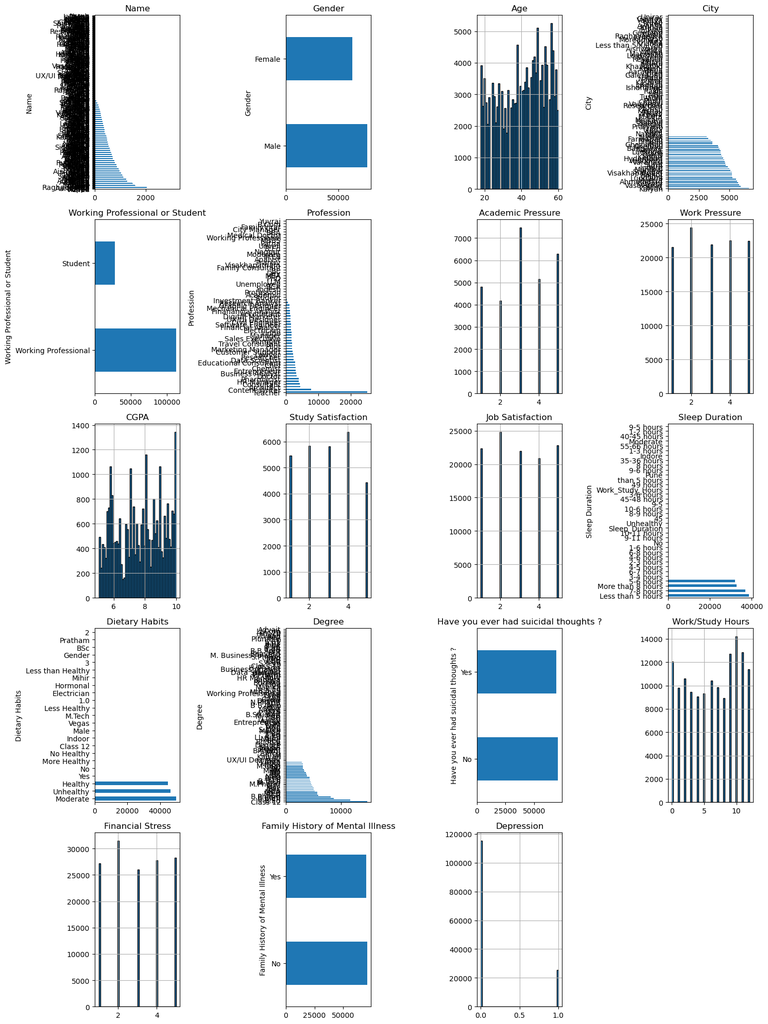

```python
fig = plt.figure(figsize=(15, 20))
for i,column in enumerate(train.columns):
    ax = fig.add_subplot(5, 4, i + 1)
    if train[column].dtype == 'object':
        train[column].value_counts().plot(kind='barh')
        ax.set_title(column)
    else:
        train[column].hist(bins = 50,ec = 'black')
        ax.set_title(column)
plt.tight_layout()
plt.show()
```

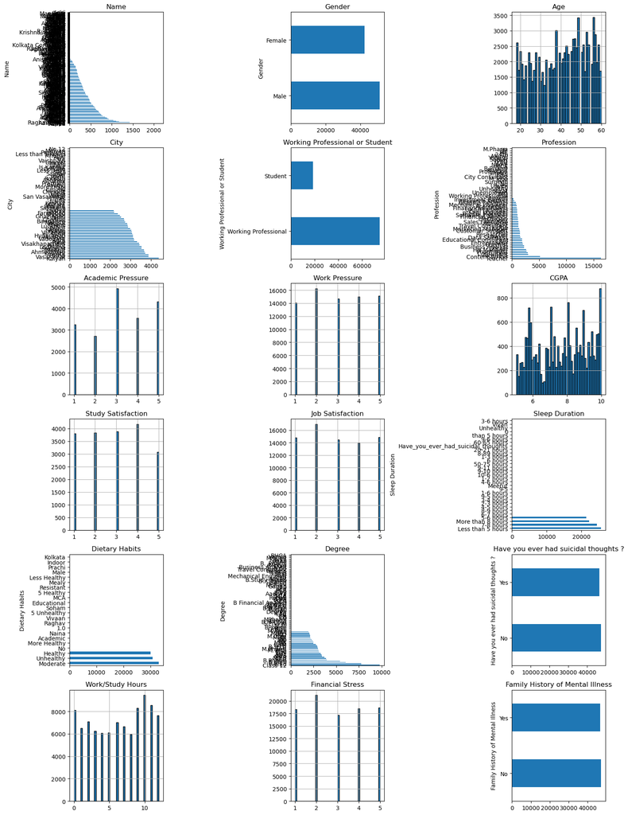

```python
fig = plt.figure(figsize=(15, 20))
for i,column in enumerate(test.columns):
    ax = fig.add_subplot(6, 3, i + 1)
    if test[column].dtype == 'object':
        test[column].value_counts().plot(kind='barh')
        ax.set_title(column)
    else:
        test[column].hist(bins = 50,ec = 'black')
        ax.set_title(column)
plt.tight_layout()
plt.show()
```

# Data preprocessing

```python
all_data_list = [train,test]
def to_lower(all_data_list):
    for i in all_data_list:
        i.columns = i.columns.str.lower().str.replace(' ', '_').str.replace('/', '_')
to_lower(all_data_list)
```

## Dtypes

```python
train['age'] = train['age'].astype('int')
test['age'] = test['age'].astype('int')

train['work_study_hours'] = train['work_study_hours'].astype('int')
test['work_study_hours'] = test['work_study_hours'].astype('int')

#train['financial_stress'] = train['financial_stress'].astype('int')
#test['financial_stress'] = test['financial_stress'].astype('int')
```

## Process missing values if necessary

### train

```python
train.shape
```

```
(140700, 19)
```

```python
train.isna().sum()
```

```
name                                          0
gender                                        0
age                                           0
city                                          0
working_professional_or_student               0
profession                                36630
academic_pressure                        112803
work_pressure                             27918
cgpa                                     112802
study_satisfaction                       112803
job_satisfaction                          27910
sleep_duration                                0
dietary_habits                                4
degree                                        2
have_you_ever_had_suicidal_thoughts_?         0
work_study_hours                              0
financial_stress                              4
family_history_of_mental_illness              0
depression                                    0
dtype: int64
```

- Join job_satisfaction + study_satisfaction => job_study_satisfaction
- Join work_pressure + academic_pressure => work_academic_pressure
- We change the values cgpa and for those who work, we change them to "no"
- Change NaN `profession` on "other"

```python
train['job_study_satisfaction'] = train['job_satisfaction']
train['job_study_satisfaction'] = train['job_study_satisfaction'].fillna(train['study_satisfaction'])
train = train.drop('job_satisfaction',axis = 1)
train = train.drop('study_satisfaction',axis = 1)
train.head()
```

| id | name | gender | age | city | working_professional_or_student | profession | academic_pressure | work_pressure | cgpa | sleep_duration | dietary_habits | degree | have_you_ever_had_suicidal_thoughts_? | work_study_hours | financial_stress | family_history_of_mental_illness | depression | job_study_satisfaction |
| --- | --- | --- | --- | --- | --- | --- | --- | --- | --- | --- | --- | --- | --- | --- | --- | --- | --- | --- |
| 0 | Aaradhya | Female | 49 | Ludhiana | Working Professional | Chef | NaN | 5.0 | NaN | More than 8 hours | Healthy | BHM | No | 1 | 2.0 | No | 0 | 2.0 |
| 1 | Vivan | Male | 26 | Varanasi | Working Professional | Teacher | NaN | 4.0 | NaN | Less than 5 hours | Unhealthy | LLB | Yes | 7 | 3.0 | No | 1 | 3.0 |
| 2 | Yuvraj | Male | 33 | Visakhapatnam | Student | NaN | 5.0 | NaN | 8.97 | 5-6 hours | Healthy | B.Pharm | Yes | 3 | 1.0 | No | 1 | 2.0 |
| 3 | Yuvraj | Male | 22 | Mumbai | Working Professional | Teacher | NaN | 5.0 | NaN | Less than 5 hours | Moderate | BBA | Yes | 10 | 1.0 | Yes | 1 | 1.0 |
| 4 | Rhea | Female | 30 | Kanpur | Working Professional | Business Analyst | NaN | 1.0 | NaN | 5-6 hours | Unhealthy | BBA | Yes | 9 | 4.0 | Yes | 0 | 1.0 |

```python
train['work_academic_pressure'] = train['work_pressure']
train['work_academic_pressure'] = train['work_academic_pressure'].fillna(train['academic_pressure'])
train = train.drop('work_pressure',axis = 1)
train = train.drop('academic_pressure',axis = 1)
train.head()
```

| id | name | gender | age | city | working_professional_or_student | profession | cgpa | sleep_duration | dietary_habits | degree | have_you_ever_had_suicidal_thoughts_? | work_study_hours | financial_stress | family_history_of_mental_illness | depression | job_study_satisfaction | work_academic_pressure |
| --- | --- | --- | --- | --- | --- | --- | --- | --- | --- | --- | --- | --- | --- | --- | --- | --- | --- |
| 0 | Aaradhya | Female | 49 | Ludhiana | Working Professional | Chef | NaN | More than 8 hours | Healthy | BHM | No | 1 | 2.0 | No | 0 | 2.0 | 5.0 |
| 1 | Vivan | Male | 26 | Varanasi | Working Professional | Teacher | NaN | Less than 5 hours | Unhealthy | LLB | Yes | 7 | 3.0 | No | 1 | 3.0 | 4.0 |
| 2 | Yuvraj | Male | 33 | Visakhapatnam | Student | NaN | 8.97 | 5-6 hours | Healthy | B.Pharm | Yes | 3 | 1.0 | No | 1 | 2.0 | 5.0 |
| 3 | Yuvraj | Male | 22 | Mumbai | Working Professional | Teacher | NaN | Less than 5 hours | Moderate | BBA | Yes | 10 | 1.0 | Yes | 1 | 1.0 | 5.0 |
| 4 | Rhea | Female | 30 | Kanpur | Working Professional | Business Analyst | NaN | 5-6 hours | Unhealthy | BBA | Yes | 9 | 4.0 | Yes | 0 | 1.0 | 1.0 |

```python
train.isna().sum()
```

```
name                                          0
gender                                        0
age                                           0
city                                          0
working_professional_or_student               0
profession                                36630
cgpa                                     112802
sleep_duration                                0
dietary_habits                                4
degree                                        2
have_you_ever_had_suicidal_thoughts_?         0
work_study_hours                              0
financial_stress                              4
family_history_of_mental_illness              0
depression                                    0
job_study_satisfaction                       15
work_academic_pressure                       21
dtype: int64
```

**We change the values `cgpa` and for those who work, we change them to "no"**

```python
train['cgpa'].describe()
```

```
count    27898.000000
mean         7.658636
std          1.464466
min          5.030000
25%          6.290000
50%          7.770000
75%          8.920000
max         10.000000
Name: cgpa, dtype: float64
```

```python
def cgpa_for_nan(cgpa_series):
    # Векторная замена значений
    cgpa_series = pd.cut(cgpa_series, bins=[0, 7, 8.5, float('inf')], labels=['low', 'medium', 'high'], right=False)
    return cgpa_series
train['cgpa'] = cgpa_for_nan(train['cgpa'])
train['cgpa'] = np.where(train['working_professional_or_student'] == 'Working Professional', 'no', train['cgpa'])
train.head()
```

| id | name | gender | age | city | working_professional_or_student | profession | cgpa | sleep_duration | dietary_habits | degree | have_you_ever_had_suicidal_thoughts_? | work_study_hours | financial_stress | family_history_of_mental_illness | depression | job_study_satisfaction | work_academic_pressure |
| --- | --- | --- | --- | --- | --- | --- | --- | --- | --- | --- | --- | --- | --- | --- | --- | --- | --- |
| 0 | Aaradhya | Female | 49 | Ludhiana | Working Professional | Chef | no | More than 8 hours | Healthy | BHM | No | 1 | 2.0 | No | 0 | 2.0 | 5.0 |
| 1 | Vivan | Male | 26 | Varanasi | Working Professional | Teacher | no | Less than 5 hours | Unhealthy | LLB | Yes | 7 | 3.0 | No | 1 | 3.0 | 4.0 |
| 2 | Yuvraj | Male | 33 | Visakhapatnam | Student | NaN | high | 5-6 hours | Healthy | B.Pharm | Yes | 3 | 1.0 | No | 1 | 2.0 | 5.0 |
| 3 | Yuvraj | Male | 22 | Mumbai | Working Professional | Teacher | no | Less than 5 hours | Moderate | BBA | Yes | 10 | 1.0 | Yes | 1 | 1.0 | 5.0 |
| 4 | Rhea | Female | 30 | Kanpur | Working Professional | Business Analyst | no | 5-6 hours | Unhealthy | BBA | Yes | 9 | 4.0 | Yes | 0 | 1.0 | 1.0 |

**Change NaN `profession` on "other"**

```python
train['profession'] = train['profession'].fillna('other')
```

```python
train.isna().sum()
```

```
name                                      0
gender                                    0
age                                       0
city                                      0
working_professional_or_student           0
profession                                0
cgpa                                      9
sleep_duration                            0
dietary_habits                            4
degree                                    2
have_you_ever_had_suicidal_thoughts_?     0
work_study_hours                          0
financial_stress                          4
family_history_of_mental_illness          0
depression                                0
job_study_satisfaction                   15
work_academic_pressure                   21
dtype: int64
```

```python
train['financial_stress'].unique()
```

```
array([ 2.,  3.,  1.,  4.,  5., nan])
```

```python
# Заменяем значения в столбце 'degree' и 'cgpa'
train.loc[train['degree'] == "5.56", 'cgpa'] = "low"
#train.loc[train['degree'] == "5.56", 'degree'] = np.nan

train.loc[train['degree'] == "5.88", 'cgpa'] = "low"
#train.loc[train['degree'] == "5.88", 'degree'] = np.nan

train.loc[train['degree'] == "5.61", 'cgpa'] = "low"
#train.loc[train['degree'] == "5.61", 'degree'] = np.nan

train.loc[train['degree'] == "7.06", 'cgpa'] = "medium"
#train.loc[train['degree'] == "7.06", 'degree'] = np.nan

train.loc[train['degree'] == "8.56", 'cgpa'] = "medium"
#train.loc[train['degree'] == "8.56", 'degree'] = np.nan

# Заменяем значения в столбце 'degree'
#train.loc[train['degree'] == "Working Professional", 'degree'] = np.nan

# Заменяем значения в столбце 'dietary_habits'
#train.loc[train['dietary_habits'] == "Male", 'dietary_habits'] = np.nan

# Заменяем значения в столбце 'sleep_duration'
train.loc[train['sleep_duration'] == "9-5", 'sleep_duration'] = "9-5 hours"
#train.loc[train['sleep_duration'] == "Unhealthy", 'sleep_duration'] = np.nan
#train.loc[train['sleep_duration'] == "Sleep_Duration", 'sleep_duration'] = np.nan
```

```python
train['cgpa'] = train['cgpa'].fillna('no')
```

```python
train.isna().sum()
```

```
name                                      0
gender                                    0
age                                       0
city                                      0
working_professional_or_student           0
profession                                0
cgpa                                      0
sleep_duration                            0
dietary_habits                            4
degree                                    2
have_you_ever_had_suicidal_thoughts_?     0
work_study_hours                          0
financial_stress                          4
family_history_of_mental_illness          0
depression                                0
job_study_satisfaction                   15
work_academic_pressure                   21
dtype: int64
```

### test

```python
test.isna().sum()
```

```
name                                         0
gender                                       0
age                                          0
city                                         0
working_professional_or_student              0
profession                               24632
academic_pressure                        75033
work_pressure                            18778
cgpa                                     75034
study_satisfaction                       75033
job_satisfaction                         18774
sleep_duration                               0
dietary_habits                               5
degree                                       2
have_you_ever_had_suicidal_thoughts_?        0
work_study_hours                             0
financial_stress                             0
family_history_of_mental_illness             0
dtype: int64
```

```python
test['job_study_satisfaction'] = test['job_satisfaction']
test['job_study_satisfaction'] = test['job_study_satisfaction'].fillna(test['study_satisfaction'])
test = test.drop('job_satisfaction',axis = 1)
test = test.drop('study_satisfaction',axis = 1)

test['work_academic_pressure'] = test['work_pressure']
test['work_academic_pressure'] = test['work_academic_pressure'].fillna(test['academic_pressure'])
test = test.drop('work_pressure',axis = 1)
test = test.drop('academic_pressure',axis = 1)
test.head()
```

| id | name | gender | age | city | working_professional_or_student | profession | cgpa | sleep_duration | dietary_habits | degree | have_you_ever_had_suicidal_thoughts_? | work_study_hours | financial_stress | family_history_of_mental_illness | job_study_satisfaction | work_academic_pressure |
| --- | --- | --- | --- | --- | --- | --- | --- | --- | --- | --- | --- | --- | --- | --- | --- | --- |
| 140700 | Shivam | Male | 53 | Visakhapatnam | Working Professional | Judge | NaN | Less than 5 hours | Moderate | LLB | No | 9 | 3.0 | Yes | 5.0 | 2.0 |
| 140701 | Sanya | Female | 58 | Kolkata | Working Professional | Educational Consultant | NaN | Less than 5 hours | Moderate | B.Ed | No | 6 | 4.0 | No | 4.0 | 2.0 |
| 140702 | Yash | Male | 53 | Jaipur | Working Professional | Teacher | NaN | 7-8 hours | Moderate | B.Arch | Yes | 12 | 4.0 | No | 1.0 | 4.0 |
| 140703 | Nalini | Female | 23 | Rajkot | Student | NaN | 6.84 | More than 8 hours | Moderate | BSc | Yes | 10 | 4.0 | No | 1.0 | 5.0 |
| 140704 | Shaurya | Male | 47 | Kalyan | Working Professional | Teacher | NaN | 7-8 hours | Moderate | BCA | Yes | 3 | 4.0 | No | 5.0 | 5.0 |

```python
def cgpa_for_nan(cgpa_series):
    # Векторная замена значений
    cgpa_series = pd.cut(cgpa_series, bins=[0, 7, 8.5, float('inf')], labels=['low', 'medium', 'high'], right=False)
    return cgpa_series
test['cgpa'] = cgpa_for_nan(test['cgpa'])
test['cgpa'] = np.where(test['working_professional_or_student'] == 'Working Professional', 'no',test['cgpa'])

test['profession'] = test['profession'].fillna('other')
```

```python
test['cgpa'] = test['cgpa'].fillna('no')
```

```python
test.isna().sum()
```

```
name                                      0
gender                                    0
age                                       0
city                                      0
working_professional_or_student           0
profession                                0
cgpa                                      0
sleep_duration                            0
dietary_habits                            5
degree                                    2
have_you_ever_had_suicidal_thoughts_?     0
work_study_hours                          0
financial_stress                          0
family_history_of_mental_illness          0
job_study_satisfaction                    8
work_academic_pressure                   12
dtype: int64
```

test.loc[test['sleep_duration'] == "8-89 hours",'sleep_duration'] = '8-9 hours' test.loc[test['sleep_duration'] == "9-5",'sleep_duration'] = '9-5 hours'